# Survival Analysis

BMEG 5103

Ariel Mundo

## Introduction

(from *Wikipedia*)

“Survival analysis is a branch of Statistics for analyzing the expected duration of time until one event occurs.

- What proportion of the population will survive past a certain time?
- Of those that survive, at what rate will they die? ”

## Other Names

- Reliability analysis
- Time-to-event analysis

### Biomedical Applications

- Cancer studies: time to an event of interest
  - Time from complete remission to relapse or progression (**time to event**)
  - Or time from diagnosis to death (**survival time**)
- Time to heart attack

Clark, et al. *Survival Analysis Part I: Basic Concepts and first analyses*. 2003

## Why can’t we do a rm-ANOVA? or a LMEM?

- Survival data is *positively skewed* (long tail to the right)
- In other words, data does not follow a normal distribution

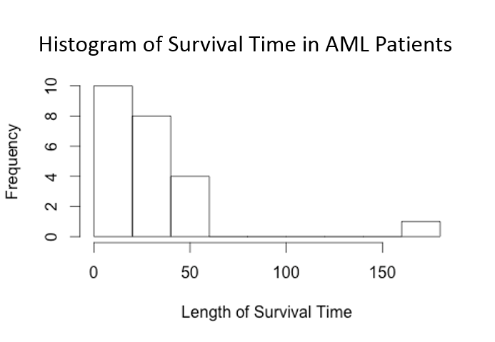

## Challenges

- Only some individuals have experienced the event
- Survival times will be *unknown* for a subset of the sample

This leads to an important concept: Censoring

Censoring

“Censoring means that the total survival time for that subject cannot be accurately determined”

Rich, et al. *A practical guide to understanding Kaplan-Meier Curves*. 2010

## Censoring

### Causes

- Subject drops out
- Lost to follow-up
- Data is not available
- The study ends before (i.e., subject survived at least until the end of the study, but we don’t know what happened after)

Rich, et al. *A practical guide to understanding Kaplan-Meier Curves*. 2010

## Censoring

### Challenges

- Censored survival times *underestimate* the true time to event
- Subjects 1,3,4,5 and 8 were *censored* before 10 years

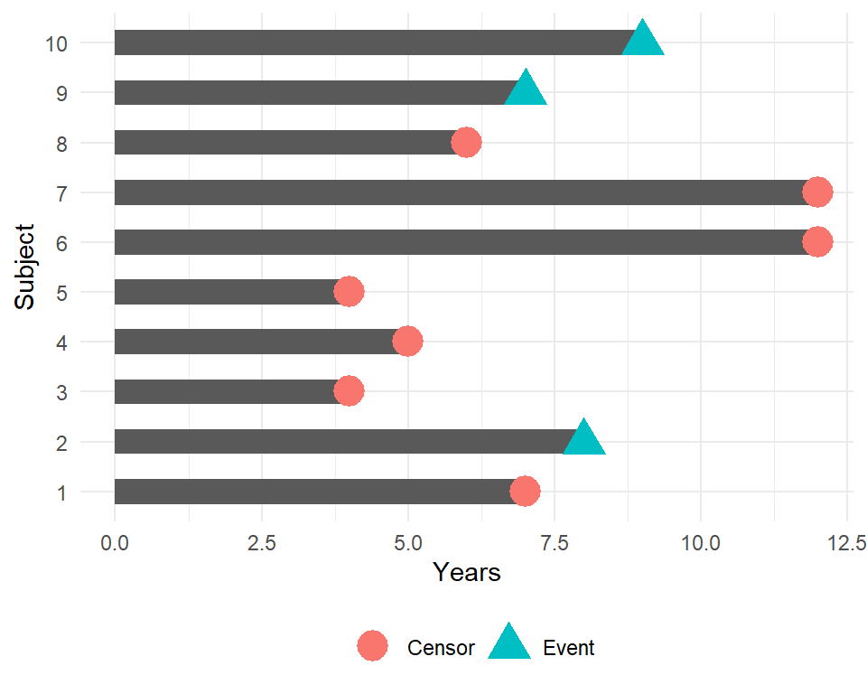

https://www.emilyzabor.com/tutorials/survival_analysis_in_r_tutorial.html

## Censoring

- In other words, patients enter the study at $t_0$, and they die at $t_0+t$
- But $t$ is unknown (either still alive or lost to follow-up)
- If the invidual was last known to be alive at time $t_0+c$ the time $c$ is called a *censored survival time*
- Because censoring occurs after the individual entered the study it is known as *right censoring* (censoring to the right of the of the last known survival time)

## An Example

From Clark et al. *A prognostic model for ovarian cancer*. BJC. 2001

- Data from an ovarian cancer study
- Patients diagnosed with primary epithelial ovarian carcinoma
  - Between January 1990 and December 1999
- Follow-up data available until the end of 2000
- By that time, 75.9% had died

## An Example

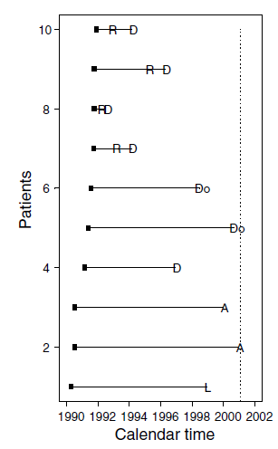

“Patient time”

R: Relapse  
D: Death from ovarian cancer  
Do: Death from another cause  
A: Attended last clinic visit (were alive!)  
L: Loss to follow-up  
X: Death

*Dashed vertical line is the date of the last follow-up*

Clark, et al. *Survival Analysis Part I: Basic Concepts and first analyses*. 2003

## Another Example

- 4 patients had a non-fatal relapse (R)
- 1 lost at follow-up
- 7 patients died (5 from ovarian cancer)
- The event of interest here is **all-cause** mortality (also called overall survival)

## An Example

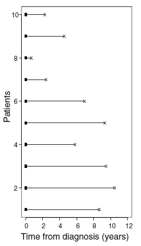

□ indicates censoring

- The data now is plotted using “survival time”
- Nonfatal relapses are ignored
- Those who have not died are **censored**
- Q: What would change if we were interested in deaths from ovarian cancer **only?**

Clark, et al. *Survival Analysis Part I: Basic Concepts and first analyses*. 2003

## An Example

- Q: What would change if we were interested in deaths from ovarian cancer **only?**
- A: Patients 5 and 6 would need to be censored as well

## Another example

- From McIllmurray and Turkie (1987), survival times of 24 patients with Dukes’ C colorectal cancer.

| Patient | Survival_date | Category |
| --- | --- | --- |
| 1 | 3 | C |
| 2 | 6 | D |
| 3 | 6 | D |
| 4 | 6 | D |
| 5 | 6 | D |
| 6 | 8 | D |

## Plotting the data

Let’s see how the plot looks like:

```r
#data$Patient<-as.factor(data$Patient)

test<-data %>%
    group_by(Patient)%>%
    rep(1:data$Survival_date)
```

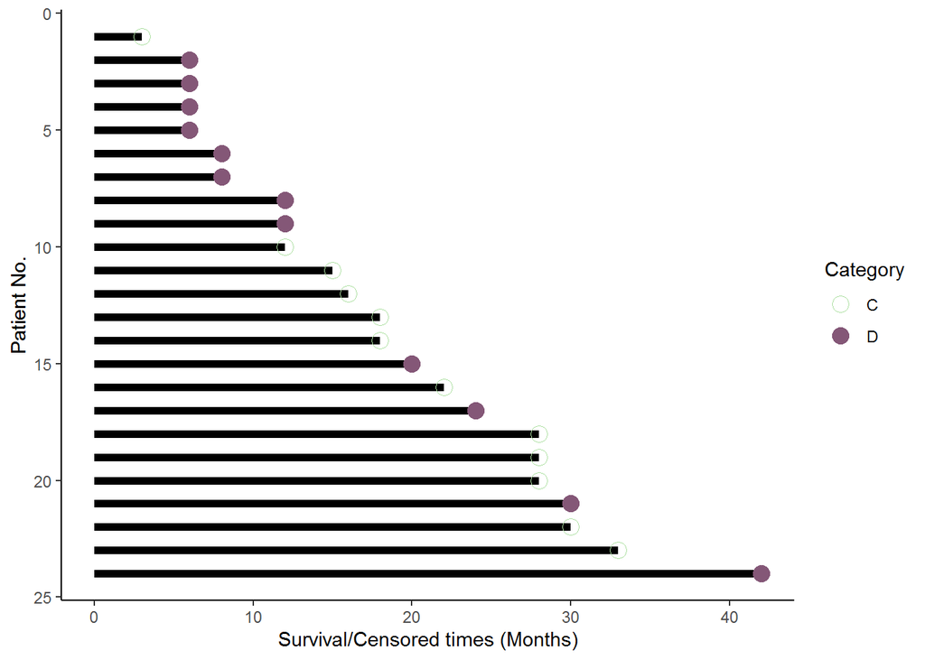

```r
data %>%
    ggplot()+
    geom_segment(aes(xend=Survival_date,yend=Patient,x=0,y=Patient),size=2)+
    scale_y_reverse()+
    labs(x="Survival/Censored times (Months)",y="Patient No.")+
    geom_point(aes(x=Survival_date,y=Patient,shape=Category,color=Category),size=4)+
    scale_shape_manual(values=c(1,16))+
    theme_classic()+
    thm1
```

- `Category` indicates censoring (C) or dead (D).

## A word about notation

- First we rank all survival/censored times from low to high
- Survival times are denoted by $t$ and Censored times are denoted by $t+$:
  - Censored time for patient 1 is 3+
  - Survival time for patient 2 is 6
- If there are ties in survival/censored data (like the 3 patients at 12 mo.), censored observations get a higher rank.
  - In this case, survival times are 12, 12 and 12+
  - Ranks would be 8, 9 and 10

## The rationale behind Kaplan-Meier

- “What is the probability that patients will survive a certain length of time?”
- How we calculate this probability:
  - The probability of surviving 42 months is the probability of surviving the 42th month having *already* survived the previous 41 months
  - The same rationale applies for surviving 41 mo.: the probability of surviving 41, *already* survived the previous 40 mo.

## The rationale behind Kaplan-Meier

$p_1$= probability of surviving at least 1 month after enrollment in trial . . . $p_{42}$= conditional probability of surviving the 42nd month after having survived month 41

$$S(42)=p_1\times p_2\times. . .\times p_{42}$$
Where $S$ denotes the overall probability of surviving 42 months after enrolling in the trial.

## The rationale behind Kaplan-Meier

In general, the probability of survival to time $t$ is

$$S(t)=p_1 \times p_2 \times...\times p_t$$

For any time $t$ (days, months, years, etc.),

$$p_t= \frac{\text{Number of patients followed for at least } t-1 \text { and who survive day } t} {\text{Number of patients alive at the end of day }t-1}$$

## The rationale behind Kaplan-Meier

- For survival data, we usually estimate the Survival Probability (aka Survivor Function)
  - Survival $S(t)$:  
    Probability that an individual survives from the time origin to a specific future time $t$

## Kaplan-Meier Survival Estimate

- Suppose that $k$ patients have events at distinct times
  $$t_1<t_2<t_3<t_4<...<t_k$$
- Think that $t$ denotes the start of a short time interval which ends at $(t+1)$.
- We then use $n_t$ as the number of patients alive at the start of the interval → these are at *risk* of death during that short interval afterwards.

## Kaplan-Meier Survival Estimate

- We assume these events are **independent**:  
  We can calculate the cumulative survival probability by multiplying the probabilities of surviving from one interval to the next.
- We denote the number of patients dying in the short time interval (just after $t$) as $d_t$.
- The number of patients surviving the interval is then $(n_t-d_t)$
- This number in turn becomes the number starting interval $n_{t+1}$

## Kaplan-Meier Surival Estimate

We can write then

$$p_t=\frac{(n_t-d_t)}{n_t},$$
which can be estimated also as

$$p_t=1-\frac{d_t}{n_t}$$

## Kaplan-Meier Survival Estimate

- When $d_t=0$ then $p_t=1$, because the number at risk does not change.
- The value of $S(t)$ changes **only** when at least one person dies.
- Therefore, we skip the times when there are no deaths (We don’t calculate $S(t)$)
- Recall that we estimate the probability of surviving at $t$ as the product of all the probabilities up to time $t$

## Kaplan-Meier Survival Estimate

- The succesive probabilites of survival $S(1), S(2)...,S(t)$ are known as the Kaplan-Meier or product-limit estimates of survival.

## Kaplan-Meier Survival Estimate

$$S(t)=S(t-1) \left( 1-\frac{d_t}{n_t} \right),$$

where:  
$S(t)$: the probability of being alive at time $t$.  
$S(t-1)$: probability of being alive at $t-1$  
$n_t$: number of patients alive just before $t$  
$d_t$: number of patients dying (events) at $t$

## Doing the calculations

Going back to the Dukes’ colorectal cancer example:

| Rank | Survival time $t$ | Number at risk $n_t$ | Observed deaths $d_t$ | $p_t=1-\frac{d_t}{n_t}$ | Survival proportion $S(t)$ |
| --- | --- | --- | --- | --- | --- |
| - | 0 | 24 | 0 | 1 | 1 |
| 1 | 3+ | 24 | 0 |  |  |
| 2 | 6 | ┓ |  |  |  |
| 3 | 6 | \| 23 | 4 | 0.8261 | 0.8261 |
| 4 | 6 | ┛ |  |  |  |
| 5 | 6 | ┓ |  |  |  |
| 6 | 8 | \|19 | 2 | 0.8947 | 0.7391 |
| 7 | 8 | ┛ |  |  |  |

## Doing the Calculations

| Rank | Survival time $t$ | Number at risk $n_t$ | Observed deaths $d_t$ | $p_t=1-\frac{d_t}{n_t}$ | Survival proportion $S(t)$ |
| --- | --- | --- | --- | --- | --- |
| - | 0 | 24 | 0 | 1 | 1 |
| 1 | 3+ | 24 | 0 |  |  |
| 2 | 6 | ┓ |  |  |  |
| 3 | 6 | \| 23 | 4 | 0.8261 | 0.8261 |
| 4 | 6 | ┛ |  |  |  |
| 5 | 6 | ┓ |  |  |  |
| 6 | 8 | \|19 | 2 | 0.8947 | 0.7391 |
| 7 | 8 | ┛ |  |  |  |
| 8 | 12 | \|17 | 2 | 0.8824 | 0.6522 |
| 9 | 12 | ┛ |  |  |  |

## The Hazard probability

The relationship between $S(t)$ and $h(t)$ is defined by:

$$h(t)=-\frac{\text{d}}{\text{d}t}[\log S(t)]$$

- If $S(t)$ is known then $h(t)$ is automatically known (and viceversa).